# Lab 4: The Normal Distribution

### Exercise 2

The normal distribution line does fit the histogram of female heights. With the lowest occuring heights reaching the ends of the distribution, and the most frequent heights in the center.

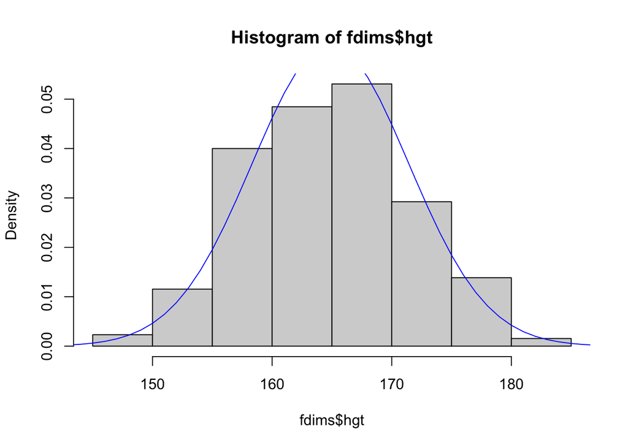

```r
fhgtmean <- mean(fdims$hgt)
fhgtsd   <- sd(fdims$hgt)

hist(fdims$hgt, probability = TRUE)
x <- 140:190
y <- dnorm(x = x, mean = fhgtmean, sd = fhgtsd)
lines(x = x, y = y, col = "blue")
```

### Exercise 3

While the simulated points are close to the distribution line, a lot of the points are above or below the line. This simulated probability plot is close to the one for the real data.

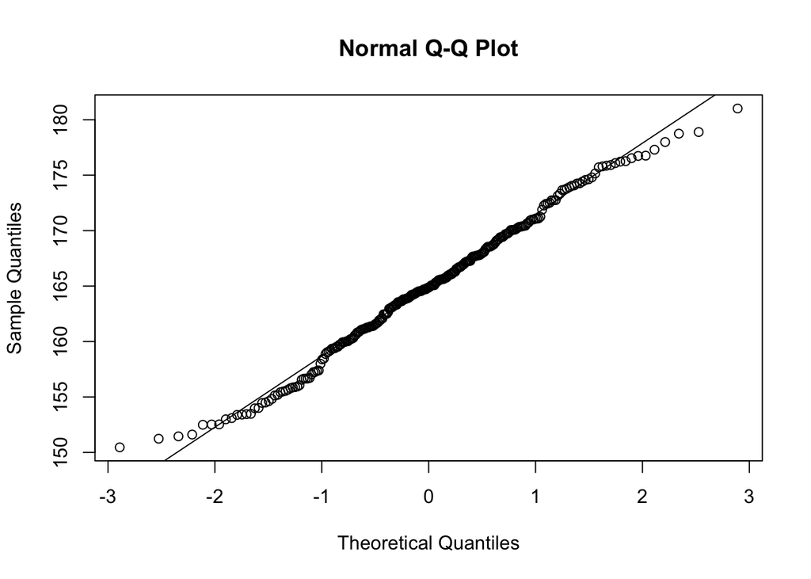

```r
sim_norm <- rnorm(n = length(fdims$hgt), mean = fhgtmean, sd = fhgtsd)
qqnorm(sim_norm)
qqline(sim_norm)
```

### Exercise 4

These created plots look very similar to the ones created for the simlulated data, which provides evidence that female heights are nearly normal.

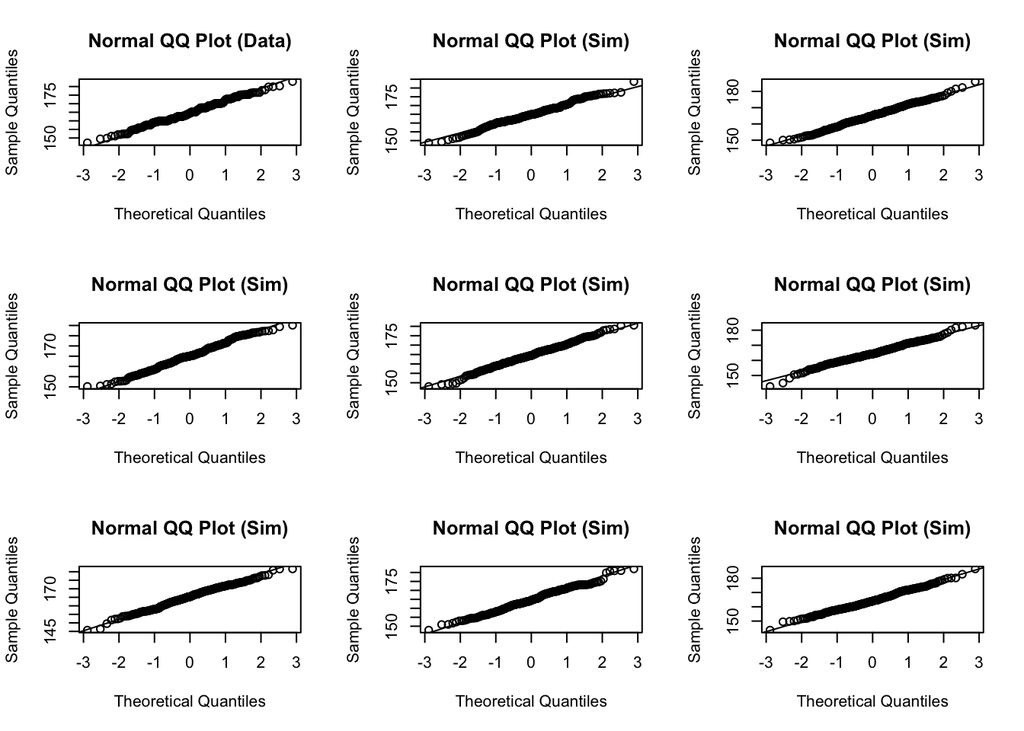

```r
qqnormsim(fdims$hgt)
```

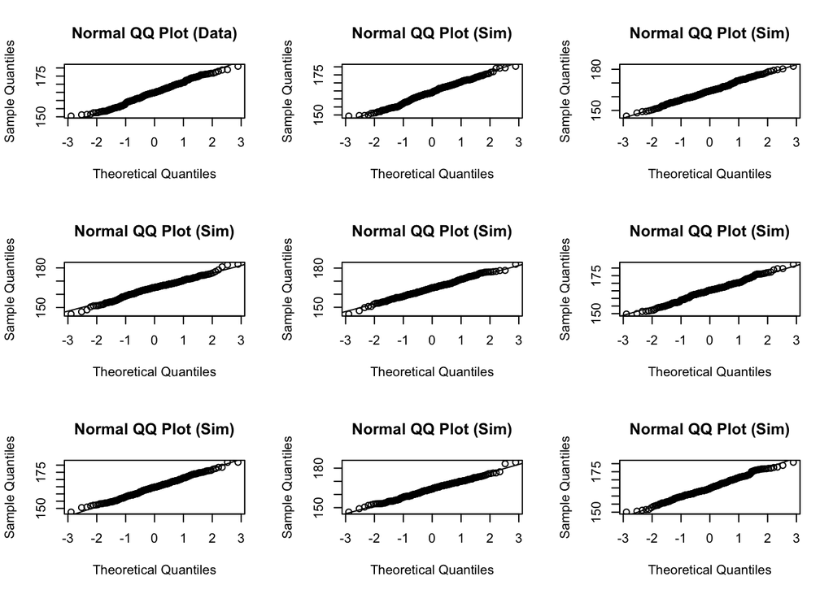

```r
qqnormsim(sim_norm)
```